# ML Lab

**Machine learning model for breast cancer data**

Installing the required libraries for Machine Learning

```r
library(caret)
library(tidyverse)
```

```r
library(ggplot2)
library(psych)
library(mice)
library(GGally)
library(rpart)
library(randomForest)
```

## Load the data

```r
breastCancerData <- read.csv(filename <- "breast-cancer.csv")
```

Remove ID column Values

```r
breastCancerData$ID<-NULL
```

Check for missing data

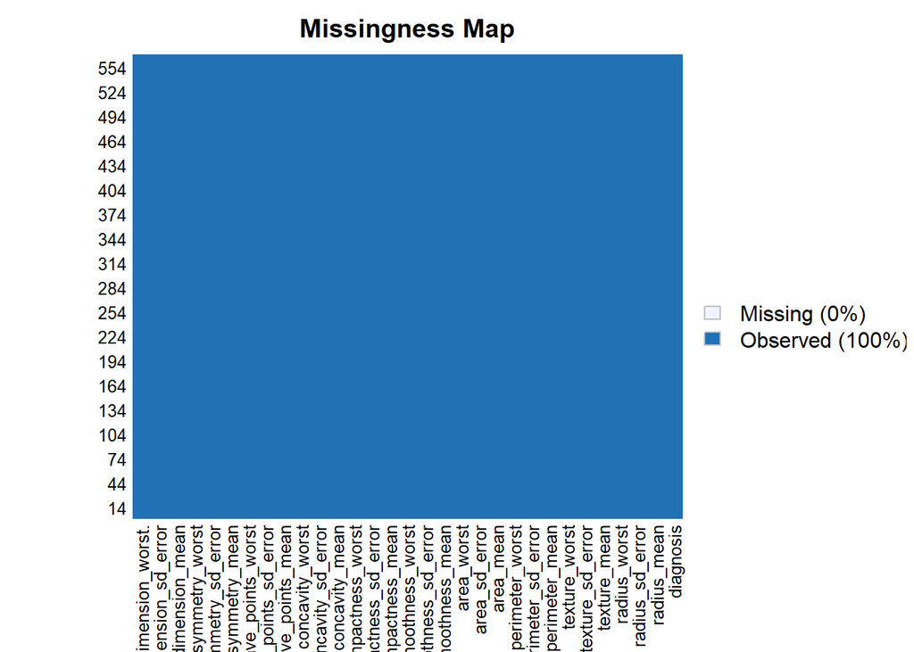

```r
library(Amelia)
missmap(breastCancerData)
```

Fetching the summary of data

```r
summary(breastCancerData)
```

```
##  diagnosis  radius_mean     radius_sd_error  radius_worst
##  B:357     Min.   : 6.981   Min.   : 9.71   Min.   : 43.79
##  M:212     1st Qu.:11.700   1st Qu.:16.17   1st Qu.: 75.17
##            Median :13.370   Median :18.84   Median : 86.24
##            Mean   :14.127   Mean   :19.29   Mean   : 91.97
##            3rd Qu.:15.780   3rd Qu.:21.80   3rd Qu.:104.10
##            Max.   :28.110   Max.   :39.28   Max.   :188.50
##   texture_mean    texture_sd_error  texture_worst     perimeter_mean
##  Min.   : 143.5   Min.   :0.05263   Min.   :0.01938   Min.   :0.00000
##  1st Qu.: 420.3   1st Qu.:0.08637   1st Qu.:0.06492   1st Qu.:0.02956
##  Median : 551.1   Median :0.09587   Median :0.09263   Median :0.06154
##  Mean   : 654.9   Mean   :0.09636   Mean   :0.10434   Mean   :0.08880
##  3rd Qu.: 782.7   3rd Qu.:0.10530   3rd Qu.:0.13040   3rd Qu.:0.13070
##  Max.   :2501.0   Max.   :0.16340   Max.   :0.34540   Max.   :0.42680
##  perimeter_sd_error perimeter_worst    area_mean       area_sd_error
##  Min.   :0.00000    Min.   :0.1060   Min.   :0.04996   Min.   :0.1115
##  1st Qu.:0.02031    1st Qu.:0.1619   1st Qu.:0.05770   1st Qu.:0.2324
##  Median :0.03350    Median :0.1792   Median :0.06154   Median :0.3242
##  Mean   :0.04892    Mean   :0.1812   Mean   :0.06280   Mean   :0.4052
##  3rd Qu.:0.07400    3rd Qu.:0.1957   3rd Qu.:0.06612   3rd Qu.:0.4789
##  Max.   :0.20120    Max.   :0.3040   Max.   :0.09744   Max.   :2.8730
##    area_worst     smoothness_mean  smoothness_sd_error smoothness_worst
##  Min.   :0.3602   Min.   : 0.757   Min.   :  6.802     Min.   :0.001713
##  1st Qu.:0.8339   1st Qu.: 1.606   1st Qu.: 17.850     1st Qu.:0.005169
##  Median :1.1080   Median : 2.287   Median : 24.530     Median :0.006380
##  Mean   :1.2169   Mean   : 2.866   Mean   : 40.337     Mean   :0.007041
##  3rd Qu.:1.4740   3rd Qu.: 3.357   3rd Qu.: 45.190     3rd Qu.:0.008146
##  Max.   :4.8850   Max.   :21.980   Max.   :542.200     Max.   :0.031130
##  compactness_mean   compactness_sd_error compactness_worst
##  Min.   :0.002252   Min.   :0.00000      Min.   :0.000000
##  1st Qu.:0.013080   1st Qu.:0.01509      1st Qu.:0.007638
##  Median :0.020450   Median :0.02589      Median :0.010930
##  Mean   :0.025478   Mean   :0.03189      Mean   :0.011796
##  3rd Qu.:0.032450   3rd Qu.:0.04205      3rd Qu.:0.014710
##  Max.   :0.135400   Max.   :0.39600      Max.   :0.052790
##  concavity_mean     concavity_sd_error  concavity_worst
##  Min.   :0.007882   Min.   :0.0008948   Min.   : 7.93
##  1st Qu.:0.015160   1st Qu.:0.0022480   1st Qu.:13.01
##  Median :0.018730   Median :0.0031870   Median :14.97
##  Mean   :0.020542   Mean   :0.0037949   Mean   :16.27
```

[output cut: 15 more lines]

```
##  Max.   :0.22260   Max.   :1.05800   Max.   :1.2520
##  fractal_dimension_mean fractal_dimension_sd_error
##  Min.   :0.00000        Min.   :0.1565
##  1st Qu.:0.06493        1st Qu.:0.2504
##  Median :0.09993        Median :0.2822
##  Mean   :0.11461        Mean   :0.2901
##  3rd Qu.:0.16140        3rd Qu.:0.3179
##  Max.   :0.29100        Max.   :0.6638
##  fractal_dimension_worst.
##  Min.   :0.05504
##  1st Qu.:0.07146
##  Median :0.08004
##  Mean   :0.08395
##  3rd Qu.:0.09208
##  Max.   :0.20750
```

Looking at the data, we can see that the diagnosis column which tells us about the bening and malignant is the most important feature. we need to convert this feature to a factor.

```r
prop.table(table(breastCancerData$diagnosis))
```

```
##
##         B         M
## 0.6274165 0.3725835
```

```r
breastCancerData$diagnosis <- factor(breastCancerData$diagnosis, levels = c("B", "M"), labels = c("Benign", "Malignant"))
```

**Data Visualization** Creating a histogram to view the radius mean

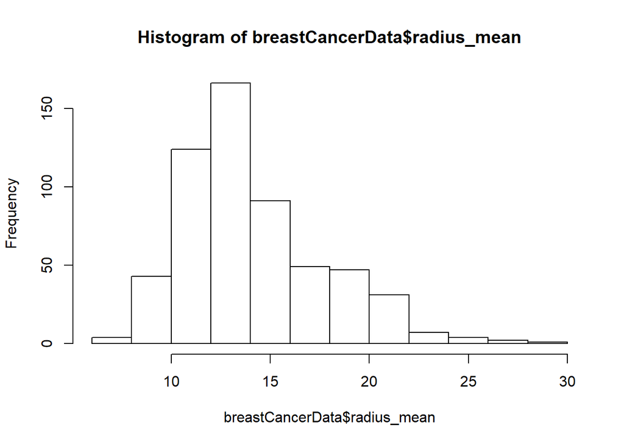

```r
  hist(breastCancerData$radius_mean)
```

**Dataset Validation** Training and testing is performed on two different datasets from the same file

```r
#split data into training and test data sets
index_data <- createDataPartition(y = breastCancerData$diagnosis,p = 0.75,list = FALSE)
training_data <- breastCancerData[index_data,]
testing_data <- breastCancerData[-index_data,]
```

Checking dimensions of dataset

```r
#Check dimensions of the split
prop.table(table(breastCancerData$diagnosis)) * 100
```

```
##
##    Benign Malignant
##  62.74165  37.25835
```

```r
prop.table(table(training_data$diagnosis)) * 100
```

```
##
##    Benign Malignant
##  62.76347  37.23653
```

```r
prop.table(table(testing_data$diagnosis)) * 100
```

```
##
##    Benign Malignant
##  62.67606  37.32394
```

For comparing the outcome of the training and testing phase let’s create separate variables that store the value of the response variable:

```r
#create objects x which holds the predictor variables and y which holds the response variables
x = training_data[,-9]
y = training_data$diagnosis
```

**Generating Naive Bayes Model using training data**

```r
#load library
library(e1071)
#create model
model = train(x,y,'nb',trControl=trainControl(method='cv',number=10))
model
```

```
## Naive Bayes
##
## 427 samples
##  30 predictor
##   2 classes: 'Benign', 'Malignant'
##
## No pre-processing
## Resampling: Cross-Validated (10 fold)
## Summary of sample sizes: 385, 384, 384, 384, 385, 384, ...
## Resampling results across tuning parameters:
##
##   usekernel  Accuracy   Kappa
##   FALSE      0.9719269  0.9404117
##    TRUE      0.9743079  0.9449164
##
## Tuning parameter 'fL' was held constant at a value of 0
## Tuning
##  parameter 'adjust' was held constant at a value of 1
## Accuracy was used to select the optimal model using the largest value.
## The final values used for the model were fL = 0, usekernel = TRUE
##  and adjust = 1.
```

We can conclude that our model is 97% accurate.

**Model Prediction and Evaluation** Perform prediction on the model created above

```r
#Predict testing set
Predict <- predict(model,newdata = testing_data )
#Get the confusion matrix to see accuracy value and other parameter values

confusionMatrix(Predict, testing_data$diagnosis)
```

```
## Confusion Matrix and Statistics
##
##            Reference
## Prediction  Benign Malignant
##   Benign        87         2
##   Malignant      2        51
##
##                Accuracy : 0.9718
##                  95% CI : (0.9294, 0.9923)
##     No Information Rate : 0.6268
##     P-Value [Acc > NIR] : <2e-16
##
##                   Kappa : 0.9398
##
##  Mcnemar's Test P-Value : 1
##
##             Sensitivity : 0.9775
##             Specificity : 0.9623
##          Pos Pred Value : 0.9775
##          Neg Pred Value : 0.9623
##              Prevalence : 0.6268
##          Detection Rate : 0.6127
##    Detection Prevalence : 0.6268
##       Balanced Accuracy : 0.9699
##
##        'Positive' Class : Benign
##
```

We conclude that our prediction model is 97% accurate. The positive class is Benign.